# Empreendedorismo Social e Negócios de Impacto Territorial

Empreendedorismo Tecnológico e Desenvolvimento Territorial · Aula 05

Prof. Dr. Luiz Diego Vidal Santos

## Unidade I Visão geral da aula

**01 · Quadro PCDO:** Empreendedorismo comercial vs. social (Austin et al., 2006).

**02 · Negócios de impacto:** Pilares socioambientais e organizações híbridas.

**03 · Teoria da Mudança:** Cadeia causal e mensuração de impacto territorial.

**04 · Finanças sociais:** Capital paciente, *grants*, *blended finance* e SIBs.

**05 · Crítica territorial:** Financeirização do social, *mission drift* e políticas públicas.

Propósito formativo Objetivo da aula

Diferenciar conceitualmente **empreendedorismo social**, **negócios de impacto** e **empreendedorismo comercial**, analisando o papel das organizações híbridas na geração de valor socioambiental e inclusão produtiva no território.

Austin · Mair & Martí Teoria da Mudança Mission Drift

**Tensão central:** Como combinar sustentabilidade financeira e missão socioambiental sem mercantilizar direitos essenciais nem perder o público vulnerável?

# Fundamentos do Empreendedorismo Social

## Conceito Quadro PCDO: comercial vs. social (Austin et al., 2006)

| Dimensão | Empreendedorismo Comercial | Empreendedorismo Social |
| --- | --- | --- |
| **Falha de Mercado** | Cria oportunidade de lucro privado | Cria oportunidade de **valor social** |
| **Missão Central** | Captura de valor econômico | Criação de **valor social/ambiental** |
| **Mobilização de Recursos** | Retorno financeiro atrai capital | Combina receitas, doações, editais e voluntariado |
| **Mensuração de Desempenho** | Lucro, ROI, *market share* | Indicadores de impacto social (mais complexos) |

Mair & Martí (2006) Catalisação de mudança social

Processo que envolve o uso inovador e a combinação de recursos para **catalisar mudança social** e atender necessidades humanas básicas não supridas pelo mercado ou pelo Estado.

**Organizações híbridas:** operam na fronteira entre a lógica de mercado (sustentabilidade financeira) e a lógica social (missão pública).

# Negócios de Impacto e Teoria da Mudança

## Método Pilares dos negócios de impacto e Teoria da Mudança

Aliança pelos Investimentos e Negócios de Impacto Os 4 pilares constitutivos

1. **Intencionalidade:** missão explícita de resolver um problema socioambiental.
2. **Solução no *core business*:** o impacto decorre da atividade principal (não é filantropia lateral).
3. **Sustentabilidade financeira:** modelo de receita próprio (venda de produtos/serviços).
4. **Mensuração de impacto:** compromisso com monitoramento e transparência de resultados.

**Insumos (*Inputs*)** $\rightarrow$ **Atividades** $\rightarrow$ **Produtos (*Outputs*)** $\rightarrow$ **Resultados (*Outcomes*)** $\rightarrow$ **Impacto Territorial (*Impact*)**

Alerta metodológico Risco do Impact Washing

Uso retórico do discurso de impacto socioambiental sem evidência causal verificável nem mudança estrutural efetiva no território.

## Síntese Teoria da Mudança e espectro de impacto

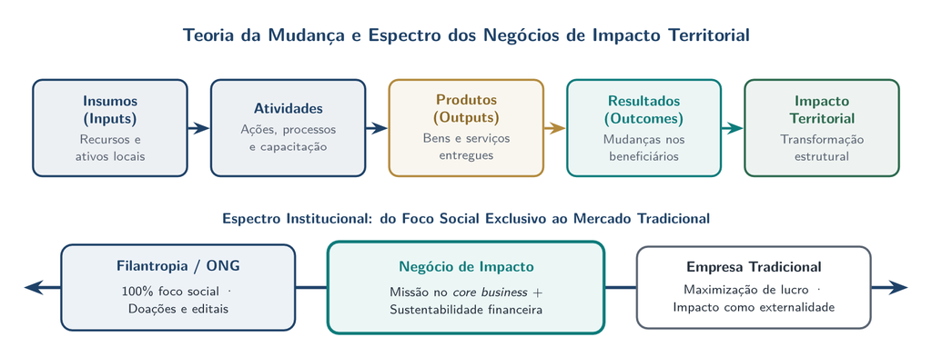

Cadeia causal da Teoria da Mudança (Insumos a Impacto Territorial) e posicionamento dos Negócios de Impacto entre filantropia e empresas tradicionais.

Teoria da Mudança e espectro dos negócios de impacto territorial Da cadeia causal (Insumos a Impacto Territorial) ao posicionamento entre filantropia pura e empresa tradicional

A validade de um negócio de impacto depende da coerência causal entre entregas operacionais e transformação estrutural mensurável.

# Finanças Sociais e Tensões Territoriais

## Conceito Instrumentos financeiros e risco de mission drift

Finanças sociais Espectro de capital de impacto

- **Fomentos não reembolsáveis (*grants*):** fase de validação e P&D social.
- *Blended Finance*: combinação de capital filantrópico/público (assume maior risco) com capital privado.
- **Títulos de Impacto Social (SIBs):** pagamento por resultado alcançado junto ao poder público.

Tensão de governança Desvio de missão (Mission Drift)

Ocorre quando a pressão por retorno financeiro e escala leva o negócio a excluir os públicos ou territórios mais vulneráveis que motivaram sua criação.

**Questão para o PLANTERR:** Negócios de impacto substituem políticas públicas universais ou devem atuar de forma complementar a elas?

## Crítica Financeirização do social e limites do hibridismo

1 · Pressão institucional O risco estrutural do mission drift

- Organizações híbridas operam sob **dupla pressão institucional**: a lógica mercantil de rentabilidade/escala e a lógica pública/comunitária de inclusão.
- Quando dependem de fundos de investimento que exigem taxas de retorno de mercado, tendem a migrar para clientes de maior renda ou cobrar tarifas excludentes (*mission drift*).

2 · Crítica sociológica Mercantilização vs. direitos sociais no território

- Transformar serviços essenciais (água, educação, saúde básica, assistência técnica rural) apenas em “oportunidades de negócios na base da pirâmide” pode legitimar a retração do Estado.
- No planejamento territorial, negócios de impacto devem **articular-se às políticas públicas estruturantes**, e não substituí-las.

## Território Comunidades tradicionais, tecnologia social e economia solidária

Enraizamento comunitário Tecnologia Social em territórios quilombolas (Dagnino, 2014)

Em comunidades quilombolas e povos tradicionais, soluções sociotécnicas partem da autogestão, dos saberes locais e da governança coletiva, evitando a imposição de pacotes tecnológicos exógenos.

Economia Solidária e políticas públicas Autonomia produtiva sem substituição de direitos (Singer, 2002)

Redes solidárias e cooperativas territoriais fortalecem a retenção de renda local quando articuladas a políticas estruturantes de regularização fundiária, água, saúde, educação e assistência técnica.

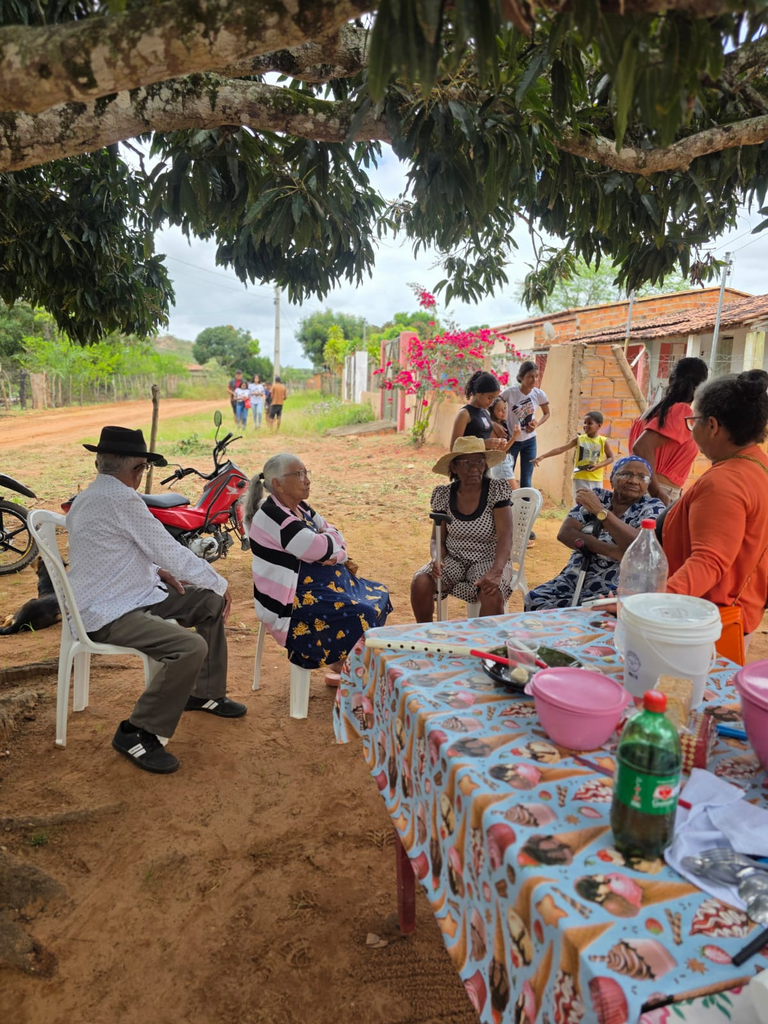

Encontro comunitário sob árvore em território quilombola.

Organização comunitária em território quilombola Governança participativa, saberes locais e tecnologia social no território

# Oficina e Leituras

## Método Construção da Teoria da Mudança e leituras

**Exercício aplicado (40 min):** Escolha um desafio territorial (acesso à água no semiárido, resíduos sólidos urbanos, conectividade rural ou restauração florestal produtiva) e desenhe:

**01 · Problema raiz:** O desafio socioambiental e o público-alvo territorial delimitados.

**02 · Solução:** A resposta tecnológica ou organizacional proposta para o contexto local.

**03 · Cadeia causal:** Insumos $\rightarrow$ Produtos $\rightarrow$ Resultados $\rightarrow$ Impacto Territorial.

**04 · Sustentabilidade:** Como gerar receita sem *mission drift* e em articulação com políticas públicas.

Bibliografia fundamental Leituras da Aula 05 e próxima aula (Eixo 4 — AV1)

- **AUSTIN, J.; STEVENSON, H.; WEI-SKILLERN, J.** *Social and commercial entrepreneurship: same, different, or both?* ETP, 2006.
- **MAIR, J.; MARTÍ, I.** *Social entrepreneurship research*. Journal of World Business, 2006.
- **DAGNINO, R.** *Tecnologia Social: contribuições conceituais e metodológicas*. EDUEPB / SciELO Livros, 2014.
- **SINGER, P.** *Introdução à Economia Solidária*. Fundação Perseu Abramo, 2002.
- **BRASIL.** *Lei da Propriedade Industrial* (Lei nº 9.279/1996 — Indicações Geográficas).